# CS 422 - Homework 1

Imaduddin Sheikh

###### Due Date: Saturday, Feb 5 2022 11:59:59 PM Chicago Time

### 2. Programming Problem

### 2.1 Explanatory Data Analysis

### Part 2.1(i)

```r
data.df = read.csv(file = 'us-covid.csv', comment='#')
```

```r
head(data.df)
```

|  | state | level | total_cases | confirmed | probable | cases_last_7_days | case_rate_per_100K | total_deaths | confirmed_deaths |
| --- | --- | --- | --- | --- | --- | --- | --- | --- | --- |
| 1 | Alabama | high | 1172663 | 851889 | 320774 | 80296 | 23916 | 16948 | 13126 |
| 2 | Alaska | high | 194176 | 0 | 0 | 21847 | 26543 | 1039 | N/A |
| 3 | Arizona | high | 1781274 | 1588439 | 192835 | 135580 | 24472 | 25624 | 22105 |
| 4 | Arkansas | high | 749824 | 0 | 0 | 61835 | 24847 | 9556 | N/A |
| 5 | California | high | 7929436 | 7482469 | 446967 | 743850 | 20068 | 78118 | N/A |
| 6 | Colorado | high | 1215931 | 1111809 | 104122 | 69191 | 21114 | 10933 | 9650 |

### Part 2.1(ii)

```r
data.df$confirmed_deaths
```

```
##  [1] "13126" "N/A"   "22105" "N/A"   "N/A"   "9650"  "7974"  "2281"  "N/A"
## [10] "N/A"   "27191" "N/A"   "3573"  "30276" "20167" "N/A"   "N/A"   "11203"
## [19] "13388" "1571"  "12978" "21107" "29373" "10543" "7200"  "N/A"   "2987"
## [28] "3012"  "N/A"   "N/A"   "28043" "N/A"   "N/A"   "17874" "N/A"   "32489"
## [37] "9037"  "5994"  "N/A"   "3132"  "N/A"   "N/A"   "2231"  "16775" "N/A"
## [46] "3911"  "N/A"   "13407" "N/A"   "N/A"   "10908" "1625"
```

```r
nrow(data.df)
```

```
## [1] 52
```

```r
nrow(data.df[data.df$confirmed_deaths=="N/A",])
```

```
## [1] 21
```

```r
data.df = subset(data.df, select = -c(confirmed_deaths))
```

```r
head(data.df)
```

|  | state | level | total_cases | confirmed | probable | cases_last_7_days | case_rate_per_100K | total_deaths |
| --- | --- | --- | --- | --- | --- | --- | --- | --- |
| 1 | Alabama | high | 1172663 | 851889 | 320774 | 80296 | 23916 | 16948 |
| 2 | Alaska | high | 194176 | 0 | 0 | 21847 | 26543 | 1039 |
| 3 | Arizona | high | 1781274 | 1588439 | 192835 | 135580 | 24472 | 25624 |
| 4 | Arkansas | high | 749824 | 0 | 0 | 61835 | 24847 | 9556 |
| 5 | California | high | 7929436 | 7482469 | 446967 | 743850 | 20068 | 78118 |
| 6 | Colorado | high | 1215931 | 1111809 | 104122 | 69191 | 21114 | 10933 |

### Part 2.1(iii)(a)

```r
library(dplyr)
head(data.df %>% arrange(desc(total_cases)), n=6)
```

|  | state | level | total_cases | confirmed | probable | cases_last_7_days | case_rate_per_100K | total_deaths |
| --- | --- | --- | --- | --- | --- | --- | --- | --- |
| 1 | California | high | 7929436 | 7482469 | 446967 | 743850 | 20068 | 78118 |
| 2 | Texas | high | 6018220 | 0 | 0 | 373823 | 20755 | 77058 |
| 3 | Florida | high | 5420755 | 0 | 0 | 224996 | 25239 | 64007 |
| 4 | Illinois | high | 2851567 | 2851567 | 0 | 168584 | 22503 | 33942 |
| 5 | Pennsylvania | high | 2592691 | 2147222 | 445469 | 104766 | 20252 | 39749 |
| 6 | Ohio | high | 2520112 | 1964622 | 555490 | 101320 | 21560 | 32489 |

### Part 2.1(iii)(b)

```r
tail(data.df %>% arrange(desc(total_cases)), n=6)
```

|  | state | level | total_cases | confirmed | probable | cases_last_7_days | case_rate_per_100K | total_deaths |
| --- | --- | --- | --- | --- | --- | --- | --- | --- |
| 47 | Hawaii | high | 202064 | 0 | 0 | 25625 | 14271 | 1135 |
| 48 | Alaska | high | 194176 | 0 | 0 | 21847 | 26543 | 1039 |
| 49 | Maine | high | 169997 | 124857 | 45140 | 7056 | 12647 | 1716 |
| 50 | Wyoming | high | 139461 | 109726 | 29735 | 8908 | 24097 | 1625 |
| 51 | District of Columbia | high | 128739 | 0 | 0 | 3032 | 18242 | 1278 |
| 52 | Vermont | high | 92563 | 0 | 0 | 7446 | 14834 | 498 |

### Part 2.1(iv)

[output not shown]

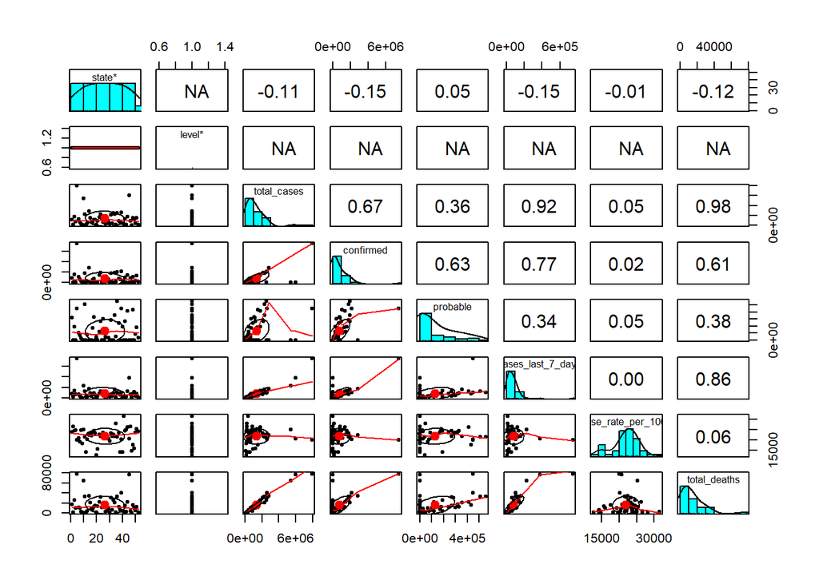

```r
library(psych)
pairs.panels(data.df)
```

```r
data.df[,"level"]
```

```
##  [1] "high" "high" "high" "high" "high" "high" "high" "high" "high" "high"
## [11] "high" "high" "high" "high" "high" "high" "high" "high" "high" "high"
## [21] "high" "high" "high" "high" "high" "high" "high" "high" "high" "high"
## [31] "high" "high" "high" "high" "high" "high" "high" "high" "high" "high"
## [41] "high" "high" "high" "high" "high" "high" "high" "high" "high" "high"
## [51] "high" "high"
```

### Part 2.1(iv)(a)

```r
select(data.df, -c("state", "level"))
```

|  | total_cases | confirmed | probable | cases_last_7_days | case_rate_per_100K | total_deaths |
| --- | --- | --- | --- | --- | --- | --- |
| 1 | 1172663 | 851889 | 320774 | 80296 | 23916 | 16948 |
| 2 | 194176 | 0 | 0 | 21847 | 26543 | 1039 |
| 3 | 1781274 | 1588439 | 192835 | 135580 | 24472 | 25624 |
| 4 | 749824 | 0 | 0 | 61835 | 24847 | 9556 |
| 5 | 7929436 | 7482469 | 446967 | 743850 | 20068 | 78118 |
| 6 | 1215931 | 1111809 | 104122 | 69191 | 21114 | 10933 |
| 7 | 687555 | 617027 | 70528 | 29875 | 19285 | 9773 |
| 8 | 242324 | 221181 | 21143 | 11448 | 24885 | 2489 |
| 9 | 128739 | 0 | 0 | 3032 | 18242 | 1278 |
| 10 | 5420755 | 0 | 0 | 224996 | 25239 | 64007 |

[output cut: 42 more lines]

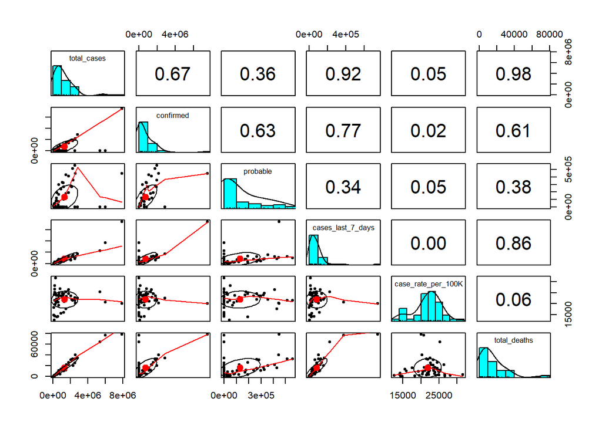

```r
pairs.panels(select(data.df, -c("state", "level")))
```

### Part 2.1(iv)(b)

‘total_cases’ and ‘total_deaths’ attributes are highly correlated, having a collinearity of 0.98.

### Part 2.1(v)

```r
cases_death.df = data.df[c("state", "total_deaths", "confirmed", "probable", "total_cases")]
cases_death.df
```

|  | state | total_deaths | confirmed | probable | total_cases |
| --- | --- | --- | --- | --- | --- |
| 1 | Alabama | 16948 | 851889 | 320774 | 1172663 |
| 2 | Alaska | 1039 | 0 | 0 | 194176 |
| 3 | Arizona | 25624 | 1588439 | 192835 | 1781274 |
| 4 | Arkansas | 9556 | 0 | 0 | 749824 |
| 5 | California | 78118 | 7482469 | 446967 | 7929436 |
| 6 | Colorado | 10933 | 1111809 | 104122 | 1215931 |
| 7 | Connecticut | 9773 | 617027 | 70528 | 687555 |
| 8 | Delaware | 2489 | 221181 | 21143 | 242324 |
| 9 | District of Columbia | 1278 | 0 | 0 | 128739 |
| 10 | Florida | 64007 | 0 | 0 | 5420755 |

[output cut: 42 more lines]

### Part 2.1(v)(a)

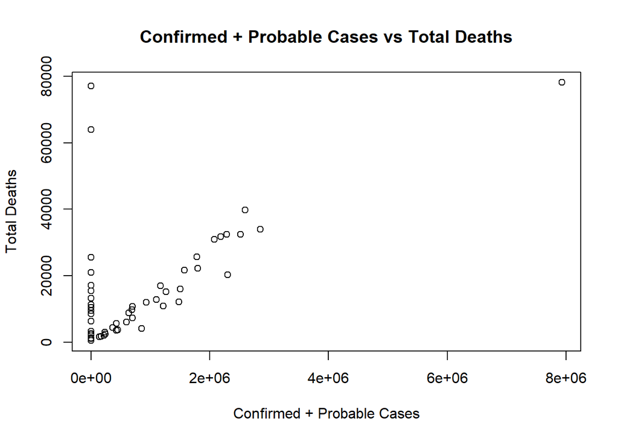

```r
plot(cases_death.df$confirmed + cases_death.df$probable, cases_death.df$total_deaths,
     xlab="Confirmed + Probable Cases", ylab="Total Deaths", main = "Confirmed + Probable Cases vs Total Deaths")
```

After plotting the scatter plot of sum of Confirmed and Probable Cases against the total number of deaths in each state, some data points can be found that have a non-zero value for total deaths but a zero value for the sum of Confirmed and Probable Cases in the corresponding state.Such condition is an anomaly because it is not possible for total deaths to be zero if there were never any cases(confirmed or probable).

### Part 2.1(v)(c)

```r
cases_death.df[cases_death.df$confirmed+cases_death.df$probable == 0,]
```

|  | state | total_deaths | confirmed | probable | total_cases |
| --- | --- | --- | --- | --- | --- |
| 2 | Alaska | 1039 | 0 | 0 | 194176 |
| 4 | Arkansas | 9556 | 0 | 0 | 749824 |
| 9 | District of Columbia | 1278 | 0 | 0 | 128739 |
| 10 | Florida | 64007 | 0 | 0 | 5420755 |
| 12 | Hawaii | 1135 | 0 | 0 | 202064 |
| 15 | Indiana | 20928 | 0 | 0 | 1569850 |
| 16 | Iowa | 8501 | 0 | 0 | 699859 |
| 19 | Louisiana | 15476 | 0 | 0 | 1084448 |
| 21 | Maryland | 13233 | 0 | 0 | 940713 |
| 24 | Minnesota | 11370 | 0 | 0 | 1264935 |

[output cut: 9 more lines]